# Taller 5

Isabella Agudelo Galindo y Kevin Leal

2023-06-24

# 1 Introducción

En el presente trabajo se realizará un análisis y comparación de los discursos de posesión presidencial de los últimos 4 presidentes electos en Colombia. Se unifican los dos discursos para los dos períodos de posesión de Álvaro Uribe Vélez (2002-2010), al igual que los dos discursos de posesión de Juan Manuel Santos (2010-2018). Por último se añaden el discurso de Iván Duque Márquez (2018-2022) y el del actual presidente electo Gustavo Francisco Petro Urrego (2022-2026).

# 2 Importar texto

Se realiza la importación de cada uno de los discursos simplificándolo con la función `unlist()` para producir un vector que contenga cada una de las líneas de texto.

```r
##### importar datos
library(readr)
library(tidyverse)
# Petro
text_petro <- unlist(c(read_csv("discurso_posesion_petro.txt", col_names = FALSE, show_col_types = FALSE)))
names(text_petro) <- NULL
# duque
text_duque <- unlist(c(read_csv("discurso_posesion_duque.txt", col_names = FALSE, show_col_types = FALSE)))
names(text_duque) <- NULL
# Santos
text_santos <- unlist(c(read_csv("discursos_posesion_santos.txt", col_names = FALSE, show_col_types = FALSE)))
names(text_santos) <- NULL
# Uribe
text_uribe <- unlist(c(read_csv("discursos_posesion_uribe.txt", col_names = FALSE, show_col_types = FALSE)))
names(text_uribe) <- NULL
```

Ahora, los textos se almacenan en un objeto tibble, entendido como una generalización del dataframe, el cual nos permitirá manipular de forma más sencilla objetos muy grandes como lo son los discursos.

```r
##### data frame formato tidy
# petro
text_petro <- tibble(line = 1:length(text_petro), text = text_petro)
# duque
text_duque <- tibble(line = 1:length(text_duque), text = text_duque)
# santos
text_santos <- tibble(line = 1:length(text_santos), text = text_santos)
# uribe
text_uribe <- tibble(line = 1:length(text_uribe), text = text_uribe)
```

# 3 Proceso de Tokenización

Para empezar con el análisis, el primer paso es realizar la tokenización del texto, lo cual convierte cada palabra en la unidad de análisis de este caso de estudio, separándolas en una casilla particular. Además las funciones en `tidytext` ya realizan una buena exportación de los datos al convertir todas las mayúsculas en minúsculas y eliminar los signos de puntuación.

```r
library(tidytext)
library(magrittr)
##### tokenizacion formato tidy
# ---------- petro ----------
text_petro %<>%
  unnest_tokens(input = text, output = word) %>%
  filter(!is.na(word))  # Eliminamos espacios en blanco
dim(text_petro)
```

```
## [1] 3840    2
```

```r
head(text_petro, n = 8)
```

```
## # A tibble: 8 × 2
##    line word
##   <int> <chr>
## 1     1 llegar
## 2     1 aquí
## 3     1 indudablemente
## 4     1 implica
## 5     1 recorrer
## 6     1 una
## 7     1 vida
## 8     1 la
```

```r
# ---------- duque ----------
text_duque %<>%
  unnest_tokens(input = text, output = word) %>%
  filter(!is.na(word))
dim(text_duque)
```

```
## [1] 5154    2
```

```r
head(text_duque, n = 8)
```

```
## # A tibble: 8 × 2
##    line word
##   <int> <chr>
## 1     1 hoy
## 2     1 desde
## 3     1 esta
## 4     1 majestuosa
## 5     1 plaza
## 6     1 que
## 7     1 lleva
## 8     1 el
```

```r
# ---------- santos ----------
text_santos %<>%
  unnest_tokens(input = text, output = word) %>%
  filter(!is.na(word))
dim(text_santos)
```

```
## [1] 8321    2
```

```r
head(text_santos, n = 8)
```

```
## # A tibble: 8 × 2
##    line word
##   <int> <chr>
## 1     1 le
## 2     1 llegó
## 3     1 la
## 4     1 hora
## 5     1 a
## 6     1 colombia
## 7     2 gracias
## 8     2 a
```

```r
# ---------- uribe ----------
text_uribe %<>%
  unnest_tokens(input = text, output = word) %>%
  filter(!is.na(word))
dim(text_uribe)
```

```
## [1] 6284    2
```

```r
head(text_uribe, n = 8)
```

```
## # A tibble: 8 × 2
##    line word
##   <int> <chr>
## 1     1 retomemos
## 2     1 el
## 3     1 lazo
## 4     1 unificador
## 5     1 de
## 6     1 la
## 7     1 ley
## 8     2 no
```

# 4 Normalización del texto

Como segundo paso para el estudio debemos realizar una normalización del texto. Esta empieza con la decisión sobre si se deben conservar los números presentes en los discursos o no. La búsqueda de caractéres numéricos para cada discurso se muestra a continuación.

```r
# ---------- petro ----------
text_petro %>%
  filter(grepl(pattern = '[0-9]', x = word)) %>%
  count(word, sort = TRUE)
```

```
## # A tibble: 6 × 2
##   word        n
##   <chr>   <int>
## 1 1           1
## 2 10          1
## 3 200.000     1
## 4 40          1
## 5 70          1
## 6 70.000      1
```

```r
# ---------- duque ----------
text_duque %>%
  filter(grepl(pattern = '[0-9]', x = word)) %>%
  count(word, sort = TRUE)
```

```
## # A tibble: 5 × 2
##   word      n
##   <chr> <int>
## 1 17        1
## 2 30        1
## 3 300       1
## 4 3d        1
## 5 4         1
```

```r
# ---------- santos ----------
text_santos %>%
  filter(grepl(pattern = '[0-9]', x = word)) %>%
  count(word, sort = TRUE)
```

```
## # A tibble: 20 × 2
##    word      n
##    <chr> <int>
##  1 2         4
##  2 1         2
##  3 100       2
##  4 2025      2
##  5 400       2
##  6 45        2
##  7 7         2
##  8 91        2
##  9 0         1
## 10 15        1
## 11 1938      1
## 12 195       1
## 13 200       1
## 14 3         1
## 15 300       1
## 16 4         1
## 17 40        1
## 18 46        1
## 19 5         1
## 20 50        1
```

```r
# ---------- uribe ----------
text_uribe %>%
  filter(grepl(pattern = '[0-9]', x = word)) %>%
  count(word, sort = TRUE)
```

```
## # A tibble: 22 × 2
##    word      n
##    <chr> <int>
##  1 200       3
##  2 20        2
##  3 2010      2
##  4 3         2
##  5 4         2
##  6 7         2
##  7 15        1
##  8 16        1
##  9 2003      1
## 10 2019      1
## # ℹ 12 more rows
```

Se observa que los discursos del presidente Gustavo Petro y el expresidente Iván Duque contienen muy pocos números (6 y 5 respectivamente) en comparación a los discursos unificados de los otros dos expresidentes (20 para Santos y 22 para Uribe). Aunque los números pueden representar cifras significativas en el momento histórico particular para cada uno de los periodos presidenciales, estos no serán considerados en la comparación de los discursos, así se procede a eliminar estos registros.

```r
##### remover texto con numeros
# ---------- petro ----------
text_petro %<>%
  filter(!grepl(pattern = '[0-9]', x = word))
dim(text_petro)
```

```
## [1] 3834    2
```

```r
# ---------- duque ----------
text_duque %<>%
  filter(!grepl(pattern = '[0-9]', x = word))
dim(text_duque)
```

```
## [1] 5149    2
```

```r
# ---------- santos ----------
text_santos %<>%
  filter(!grepl(pattern = '[0-9]', x = word))
dim(text_santos)
```

```
## [1] 8291    2
```

```r
# ---------- uribe ----------
text_uribe %<>%
  filter(!grepl(pattern = '[0-9]', x = word))
dim(text_uribe)
```

```
## [1] 6255    2
```

# 5 Eliminación de stop words

Ahora, se exporta una lista de “stop words” con 451 palabras en español que nos permitirá eliminar todas las palabras que no aportan información relevante para este análisis, como lo son conectores, artículos o verbos auxiliares de uso común. Una vez hecho esto, vemos como se reducen considerablemente la cantidad de registros en los archivos.

```r
###### stop words
stop_words_es <- tibble(word = unlist(c(read.table("stop_words_spanish.txt", quote="\"", comment.char=""))), lexicon = "custom")
dim(stop_words_es)
```

```
## [1] 451   2
```

```r
##### remover stop words
# ---------- petro ----------
text_petro %<>%
  anti_join(x = ., y = stop_words_es)
dim(text_petro)
```

```
## [1] 1597    2
```

```r
head(text_petro, n = 8)
```

```
## # A tibble: 8 × 2
##    line word
##   <int> <chr>
## 1     1 llegar
## 2     1 indudablemente
## 3     1 implica
## 4     1 recorrer
## 5     1 vida
## 6     1 vida
## 7     1 inmensa
## 8     1 recorre
```

```r
# ---------- duque ----------
text_duque %<>%
  anti_join(x = ., y = stop_words_es)
dim(text_duque)
```

```
## [1] 2110    2
```

```r
head(text_duque, n = 8)
```

```
## # A tibble: 8 × 2
##    line word
##   <int> <chr>
## 1     1 majestuosa
## 2     1 plaza
## 3     1 nombre
## 4     1 libertador
## 5     1 simón
## 6     1 bolívar
## 7     2 llega
## 8     2 presidencia
```

```r
# ---------- santos ----------
text_santos %<>%
  anti_join(x = ., y = stop_words_es)
dim(text_santos)
```

```
## [1] 3466    2
```

```r
head(text_santos, n = 8)
```

```
## # A tibble: 8 × 2
##    line word
##   <int> <chr>
## 1     1 hora
## 2     1 colombia
## 3     2 gracias
## 4     2 dios
## 5     2 gracias
## 6     2 colombia
## 7     3 país
## 8     3 maravillosa
```

```r
# ---------- uribe ----------
text_uribe %<>%
  anti_join(x = ., y = stop_words_es)
dim(text_uribe)
```

```
## [1] 3039    2
```

```r
head(text_uribe, n = 8)
```

```
## # A tibble: 8 × 2
##    line word
##   <int> <chr>
## 1     1 retomemos
## 2     1 lazo
## 3     1 unificador
## 4     1 ley
## 5     2 venimos
## 6     2 quejarnos
## 7     3 vidas
## 8     3 seres
```

Para finalizar con la normalización, se remueven los acentos del idioma español después de haber eliminado las stop words, así se evita remover palabras que sin acento hubieran podido ser eliminadas en el paso anterior.

```r
##### remover acentos
replacement_list <- list('á' = 'a', 'é' = 'e', 'í' = 'i', 'ó' = 'o', 'ú' = 'u')
# ---------- petro ----------
text_petro %<>%
  mutate(word = chartr(old = names(replacement_list) %>% str_c(collapse = ''),
                       new = replacement_list %>% str_c(collapse = ''),
                       x = word))
# ---------- duque ----------
text_duque %<>%
  mutate(word = chartr(old = names(replacement_list) %>% str_c(collapse = ''),
                       new = replacement_list %>% str_c(collapse = ''),
                       x = word))
# ---------- santos ----------
text_santos %<>%
  mutate(word = chartr(old = names(replacement_list) %>% str_c(collapse = ''),
                       new = replacement_list %>% str_c(collapse = ''),
                       x = word))
# ---------- uribe ----------
text_uribe %<>%
  mutate(word = chartr(old = names(replacement_list) %>% str_c(collapse = ''),
                       new = replacement_list %>% str_c(collapse = ''),
                       x = word))
```

# 6 Tokens más frecuentes

Una vez hecho el tratamiento a estas bases de datos, podemos empezar el análisis con lo básico de la estadística descriptiva. Se realiza un conteo de las palabras y se identifican las modas o las palabras más frecuentes para cada uno de los discursos, A continuación se presentan el top 10 en cada caso.

```r
##### top 10 de tokens mas frecuentes
# ---------- petro ----------
text_petro %>%
  count(word, sort = TRUE) %>%
  head(n = 10)
```

```
## # A tibble: 10 × 2
##    word            n
##    <chr>       <int>
##  1 colombia       38
##  2 paz            19
##  3 vida           16
##  4 sociedad       14
##  5 gobierno       10
##  6 mundo          10
##  7 humanidad       8
##  8 pueblo          8
##  9 colombianas     7
## 10 economia        7
```

```r
# ---------- duque ----------
text_duque %>%
  count(word, sort = TRUE)  %>%
  head(n = 10)
```

```
## # A tibble: 10 × 2
##    word            n
##    <chr>       <int>
##  1 colombia       40
##  2 pais           18
##  3 colombianos    16
##  4 construir      15
##  5 estado         15
##  6 legalidad      14
##  7 equidad        13
##  8 gobierno       12
##  9 significa      12
## 10 justicia       11
```

```r
# ---------- santos ----------
text_santos %>%
  count(word, sort = TRUE)  %>%
  head(n = 10)
```

```
## # A tibble: 10 × 2
##    word            n
##    <chr>       <int>
##  1 colombia       58
##  2 pais           46
##  3 colombianos    37
##  4 gobierno       31
##  5 paz            30
##  6 justicia       20
##  7 social         17
##  8 desarrollo     16
##  9 seguridad      16
## 10 hora           15
```

```r
# ---------- uribe ----------
text_uribe %>%
  count(word, sort = TRUE)  %>%
  head(n = 10)
```

```
## # A tibble: 10 × 2
##    word            n
##    <chr>       <int>
##  1 estado         29
##  2 seguridad      28
##  3 paz            22
##  4 social         20
##  5 democracia     19
##  6 nacion         18
##  7 crecimiento    15
##  8 pueblo         15
##  9 democratica    14
## 10 libertad       14
```

No es sorprendente ver que entre los discursos se comparten varias palabras como las más frecuentes teniendo en cuenta el carácter político de los textos, sin embargo, cabe recordar que en el caso de Juan Manuel Santos y Álvaro Uribe Vélez se cuentan con dos discursos que equivalen aproximadamente al doble de palabras que las presentes en los discursos de Gustavo Petro e Iván Duque. Para una mejor visualización se presenta un diagrama de barras con las frecuencias de las palabras para cada discurso. En el caso de Petro y Duque se establece un filtro en la frecuencia mayor que 6 y para Santos y Uribe el filtro es de 9.

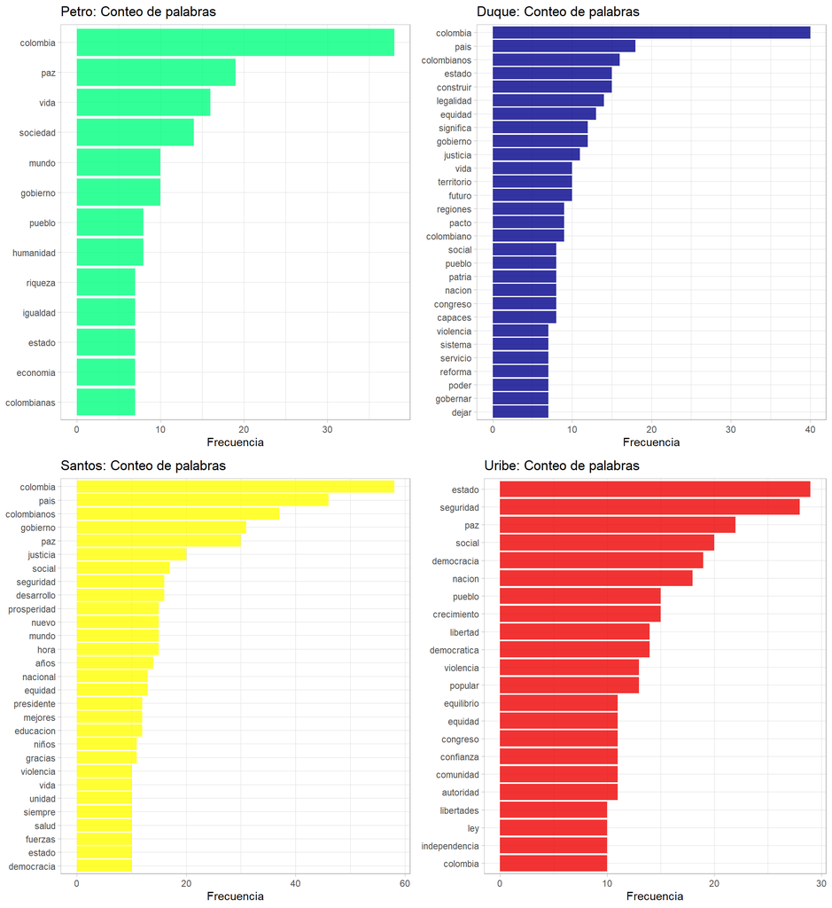

Como una alternativa para mejorar la visualización se realizan nubes de palabras, que ilustra un máximo de 25 palabras para cada discurso cuyo tamaño es proporcional a su frecuencia en los textos

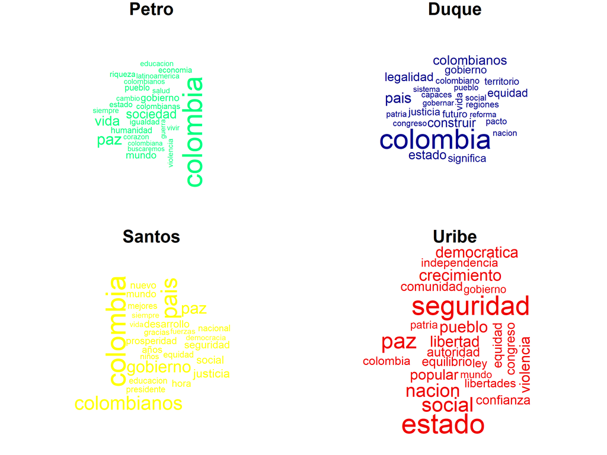

Ahora, para poder realizar comparaciones más directas entre los discursos, se calculan primero las frecuencias relativas de todas las palabras que son mencionadas en ellos, por lo cual, algunas tendrán frecuencia cero si no fueron mencionadas dentro de las alocución del respectivo estadista.

```r
##### frecuencias relativas de las palabras
bind_rows(mutate(.data = text_petro, author = "petro"),
                       mutate(.data = text_duque, author = "duque"),
                       mutate(.data = text_santos, author = "santos"),
                       mutate(.data = text_uribe, author = "uribe")) %>%
  count(author, word) %>%
  group_by(author) %>%
  mutate(proportion = n/sum(n)) %>%
  select(-n) %>%
  spread(author, proportion, fill = 0) -> frec  # importante!
frec %<>%
  select(word, petro, duque, santos, uribe)
dim(frec)
```

```
## [1] 4353    5
```

```r
head(frec, n = 10)
```

```
## # A tibble: 10 × 5
##    word              petro    duque   santos    uribe
##    <chr>             <dbl>    <dbl>    <dbl>    <dbl>
##  1 abandona       0        0        0        0.000329
##  2 abandonar      0        0        0        0.000329
##  3 abandono       0        0.000474 0.000289 0
##  4 abastecimiento 0        0.000474 0        0
##  5 aberracion     0.000626 0        0        0
##  6 abierta        0        0        0.000289 0
##  7 abiertas       0.000626 0        0        0.000658
##  8 abierto        0        0        0.000577 0
##  9 abnegada       0        0        0        0.000329
## 10 abogados       0        0        0.000289 0
```

En la siguiente tabla se ordenan de forma anidada, de acuerdo a los respectivos periodos presidenciales, desde el actual hasta el más antiguo, las 15 palabras más frecuentes en común entre los discursos.

```r
# orden anidado respecto al actual presidente hacia el último expresidente
frec %>%
  filter(petro !=0, duque != 0, santos!=0, uribe!=0) %>%
  arrange(desc(petro), desc(duque), desc(santos), desc(uribe)) -> frec_comun
dim(frec_comun)
```

```
## [1] 145   5
```

```r
head(frec_comun, n = 15)
```

```
## # A tibble: 15 × 5
##    word          petro   duque   santos    uribe
##    <chr>         <dbl>   <dbl>    <dbl>    <dbl>
##  1 colombia    0.0238  0.0190  0.0167   0.00329
##  2 paz         0.0119  0.00237 0.00866  0.00724
##  3 vida        0.0100  0.00474 0.00289  0.000658
##  4 sociedad    0.00877 0.00142 0.00231  0.00132
##  5 gobierno    0.00626 0.00569 0.00894  0.00296
##  6 mundo       0.00626 0.00142 0.00433  0.00263
##  7 pueblo      0.00501 0.00379 0.00144  0.00494
##  8 estado      0.00438 0.00711 0.00289  0.00954
##  9 economia    0.00438 0.00237 0.00144  0.00230
## 10 riqueza     0.00438 0.00190 0.000289 0.00165
## 11 colombianos 0.00376 0.00758 0.0107   0.000987
## 12 violencia   0.00376 0.00332 0.00289  0.00428
## 13 educacion   0.00376 0.00237 0.00346  0.00132
## 14 salud       0.00376 0.00237 0.00289  0.000329
## 15 corazon     0.00376 0.00237 0.00173  0.000658
```

Además, se encuentra que de todas las palabras en conjunto, solo el 3.33% son mencionadas en los 4 discursos.

```r
###### proporcion palabras en comun
dim(frec_comun)[1]/dim(frec)[1]
```

```
## [1] 0.03331036
```

Una vez calculadas las frecuencias, se deciden calcular los coeficientes de correlación lineal de Pearson entre cada par de alocuciones para evaluar que tan parecidos son sus contenidos.

```r
library(gtools)

Pres<-c("Petro","Duque","Santos","Uribe")
comb<-combinations(4, 2, 2:5)
frec<-as.data.frame(frec)
frec_comun<-as.data.frame(frec_comun)
Tab<-matrix(0,6,2)
for(i in 1:6){
Tab[i,1]<-cor.test(x =frec[,comb[i,1]], y =frec[,comb[i,2]])$estimate
Tab[i,2]<-cor.test(x =frec_comun[,comb[i,1]], y =frec_comun[,comb[i,2]])$estimate
}

Tabla<-cbind(Pres[combinations(4, 2, 1:4)[,1]],Pres[combinations(4, 2, 1:4)[,2]],round(Tab,3))
colnames(Tabla)<-c("Discurso 1 ", "Discurso 2", "Corr P. Total","Corr P. común")
```

|  | Discurso 1 | Discurso 2 | Corr P. Total | Corr P. común |
| --- | --- | --- | --- | --- |
|  | Petro | Duque | 0.48 | 0.694 |
|  | Petro | Santos | 0.536 | 0.673 |
|  | Petro | Uribe | 0.291 | 0.356 |
|  | Duque | Santos | 0.595 | 0.768 |
|  | Duque | Uribe | 0.33 | 0.339 |
|  | Santos | Uribe | 0.394 | 0.394 |

# 7 Conclusiones de los conteos.

Se observa que, en todos los discursos, excepto en el de Uribe, la palabra con mayor frecuencia es “Colombia”, en tanto que “paz” está en el top 10 de todos excepto en el de Duque. El discurso de Petro se distingue con palabras importantes como “vida”, “humanidad” y “economía”; el de Duque por “construir”, “legalidad” y “equidad”; los de Santos por “desarrollo”, “justicia” y “social” y los discursos de Uribe por “seguridad”, “crecimiento” y “democracia”. Es de resaltar que, mientras que en los discursos de Santos y de Duque la tercera palabra más frecuente es “colombianos”, en el de Petro se destaca la palabra “colombianas”, marcando una diferencia en lo que respecta a inclusión.

Por otro lado, en el conteo de los registros, es evidente que el número de palabras con una frecuencia mayor a 6 es menor en el discurso de Petro, el cual es el más corto y en donde parece se usó mayor variedad de palabras. La alocución de Duque es más reiterativa y las frecuencias en el caso de Santos y de Uribe son mayores puesto que se están considerando dos discursos, por este motivo, el tamaño y el número de las palabras en los gráficos de nube para estos dos archivos es mayor.

Las palabras en común para los 4 discursos, con una proporción del 3.33%, muestran la índole política del análisis, al resaltar palabras como “pueblo”, “Estado”, “riqueza”, “violencia”, “educación” y “salud”. La similaridad en los discursos, vista por medio de las correlaciones entre las frecuencias de los registros, muestran que Petro tiende a usar palabras semejantes a las mencionadas por Santos y diferentes a las del discurso de Uribe, puesto que tienen la mayor y menor correlación respectivamente. En contraste, dentro de las palabras que usan en común, Duque las emplea con frecuencias parecidas a las de Santos y diferentes a las de Uribe, evidenciando que los discursos de Uribe son los que más diferencias presentan con todos los demás.

# 8 Análisis de sentimiento

El siguiente paso es realizar un análisis de sentimiento de las palabras en cada texto. Para esto, se utiliza un diccionario pre-existente (y editado según el interés del estudio) de palabras positivas y uno de palabras conisderadas negativas.

```r
# diccionarios
positive_words <- read_csv("positive_words_es.txt", col_names = "word", show_col_types = FALSE) %>%
  mutate(sentimiento = "Positivo")
negative_words <- read_csv("negative_words_es.txt", col_names = "word", show_col_types = FALSE) %>%
  mutate(sentimiento = "Negativo")
sentiment_words <- bind_rows(positive_words, negative_words)
sentiment_words %>%
  count(sentimiento)
```

```
## # A tibble: 2 × 2
##   sentimiento     n
##   <chr>       <int>
## 1 Negativo     2716
## 2 Positivo     1555
```

Se obtiene el porcentaje de palabras negativas y el de palabras positivas para cada discurso

```r
# ---------- petro ----------
text_petro %>%
  inner_join(sentiment_words) %>%
  count(word, sentimiento, sort = TRUE) -> sent_petro

sent_petro %>%
  group_by(sentimiento) %>%
  summarise(conteo = sum(n)/sum(sent_petro$n)*100) -> porc_petro
# ---------- duque ----------
text_duque %>%
  inner_join(sentiment_words) %>%
  count(word, sentimiento, sort = TRUE) -> sent_duque

sent_duque %>%
  group_by(sentimiento) %>%
  summarise(conteo = sum(n)/sum(sent_duque$n)*100) -> porc_duque
# ---------- santos ----------
text_santos %>%
  inner_join(sentiment_words) %>%
  count(word, sentimiento, sort = TRUE) -> sent_santos

sent_santos %>%
  group_by(sentimiento) %>%
  summarise(conteo = sum(n)/sum(sent_santos$n)*100) -> porc_santos
# ---------- uribe ----------
text_uribe %>%
  inner_join(sentiment_words) %>%
  count(word, sentimiento, sort = TRUE) -> sent_uribe

sent_uribe %>%
  group_by(sentimiento) %>%
  summarise(conteo = sum(n)/sum(sent_uribe$n)*100) -> porc_uribe

Porcentajes <- cbind(porc_uribe, porc_santos$conteo, porc_duque$conteo, porc_petro$conteo)
colnames(Porcentajes) <- (c("Sentimiento", "% Uribe", "% Santos", "% Duque", "% Petro"))
Porcentajes
```

```
##   Sentimiento  % Uribe % Santos  % Duque  % Petro
## 1    Negativo 32.70677  22.2031 37.82991 36.73469
## 2    Positivo 67.29323  77.7969 62.17009 63.26531
```

Con estos diccionarios podemos crear un gráfico de barras para cada personaje mostrando las palabras positivas y negativas con una frecuencia mayor que 2 en el caso de Petro y Duque, y mayor que 3 para Santos y Uribe.

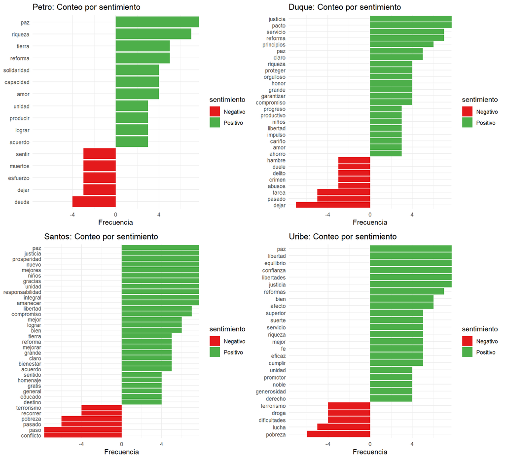

De manera similar a los conteos anteriores, es posible graficar una nube de máximo 50 palabras, distinguiendo las positivas de las negativas para poder realizar una comparación más sencilla.

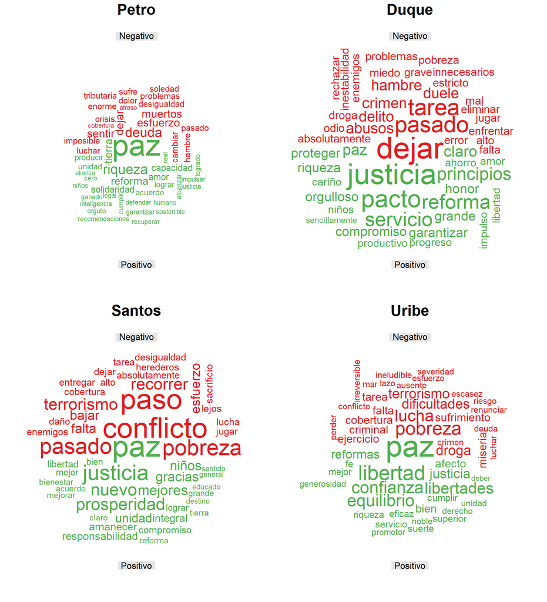

# 9 Conclusiones para los sentimientos

En general, por medio de los diagramas de barras, podemos observar que son más la cantidad de palabras positivas mencionadas en los discursos que las palabras negativas, además de que se mencionan con frecuencias considerablemente mayores. Sin embargo, es resaltar que los expresidentes Iván Duque y Juan Manuel Santos tienden a repetir más las palabras negativas que el presidente Gustavo Petro y el expresidente Álvaro Uribe.

En cuanto a las palabras negativas, las más comunes están relacionadas a temas económicos como “desigualdad”, “deuda” o “pobreza”, aunque esta última no es mencionada por el presidente Petro. También comparten temas de conflicto como “crimen”, “terrorismo”, “muertos” o “delito”. A su vez, resulta interesante que los expresidentes Duque y Uribe son los únicos en incluir “droga” en sus discursos, así como Petro es el único que menciona la palabra “tributaria”, y Duque es el único que menciona “odio”.

# 10 Bigramas

Todo el análisis presentado hasta el momento se ha basado en procedimientos para unigramas. Ahora se presentarán resultados teniendo en cuenta los bigramas. Para esto, debemos realizar nuevamente la importación de los textos originales.

```r
##### importar datos
text_petro <- unlist(c(read_csv("discurso_posesion_petro.txt", col_names = FALSE, show_col_types = FALSE)))
names(text_petro) <- NULL
text_petro <- tibble(line = 1:length(text_petro), text = text_petro)
# duque
text_duque <- unlist(c(read_csv("discurso_posesion_duque.txt", col_names = FALSE, show_col_types = FALSE)))
names(text_duque) <- NULL
text_duque <- tibble(line = 1:length(text_duque), text = text_duque)
# Santos
text_santos <- unlist(c(read_csv("discursos_posesion_santos.txt", col_names = FALSE, show_col_types = FALSE)))
names(text_santos) <- NULL
text_santos <- tibble(line = 1:length(text_santos), text = text_santos)
# Uribe
text_uribe <- unlist(c(read_csv("discursos_posesion_uribe.txt", col_names = FALSE, show_col_types = FALSE)))
names(text_uribe) <- NULL
text_uribe <- tibble(line = 1:length(text_uribe), text = text_uribe)
```

Una vez importados, la tokenización ya no será realizada por cada palabra, sino que las nuevas unidades de análisis serán todos los pares de palabras presentes en los discursos.

```r
##### tokenizar en bigramas
#petro
text_petro %>%
  unnest_tokens(tbl = ., input = text, output = bigram, token = "ngrams", n = 2) %>%
  filter(!is.na(bigram)) -> text_petro_bi
dim(text_petro_bi)
```

```
## [1] 3591    2
```

```r
head(text_petro_bi, n = 8)
```

```
## # A tibble: 8 × 2
##    line bigram
##   <int> <chr>
## 1     1 llegar aquí
## 2     1 aquí indudablemente
## 3     1 indudablemente implica
## 4     1 implica recorrer
## 5     1 recorrer una
## 6     1 una vida
## 7     1 vida la
## 8     1 la vida
```

```r
#duque
text_duque %>%
  unnest_tokens(tbl = ., input = text, output = bigram, token = "ngrams", n = 2) %>%
  filter(!is.na(bigram)) -> text_duque_bi
dim(text_duque_bi)
```

```
## [1] 4957    2
```

```r
head(text_duque_bi, n = 8)
```

```
## # A tibble: 8 × 2
##    line bigram
##   <int> <chr>
## 1     1 hoy desde
## 2     1 desde esta
## 3     1 esta majestuosa
## 4     1 majestuosa plaza
## 5     1 plaza que
## 6     1 que lleva
## 7     1 lleva el
## 8     1 el nombre
```

```r
#santos
text_santos %>%
  unnest_tokens(tbl = ., input = text, output = bigram, token = "ngrams", n = 2) %>%
  filter(!is.na(bigram)) -> text_santos_bi
dim(text_santos_bi)
```

```
## [1] 7927    2
```

```r
head(text_santos_bi, n = 8)
```

```
## # A tibble: 8 × 2
##    line bigram
##   <int> <chr>
## 1     1 le llegó
## 2     1 llegó la
## 3     1 la hora
## 4     1 hora a
## 5     1 a colombia
## 6     2 gracias a
## 7     2 a dios
## 8     2 dios gracias
```

```r
#uribe
text_uribe %>%
  unnest_tokens(tbl = ., input = text, output = bigram, token = "ngrams", n = 2) %>%
  filter(!is.na(bigram)) -> text_uribe_bi
dim(text_uribe_bi)
```

```
## [1] 5978    2
```

```r
head(text_uribe_bi, n = 8)
```

```
## # A tibble: 8 × 2
##    line bigram
##   <int> <chr>
## 1     1 retomemos el
## 2     1 el lazo
## 3     1 lazo unificador
## 4     1 unificador de
## 5     1 de la
## 6     1 la ley
## 7     2 no venimos
## 8     2 venimos a
```

Nuevamente, se eliminan cualquier par de palabras que contenga una stop word, puesto que siguen sin aportar información relevante. Sin embargo, en este paso se separa cada palabra en una columna distinta, y en una tercera columna del archivo se almacena la frecuencia de esta pareja, lo cual será útil para la conformación de la red de los discursos.

```r
##### omitir stop words
text_petro_bi %>%
  separate(bigram, c("word1", "word2"), sep = " ") %>%
  filter(!grepl(pattern = '[0-9]', x = word1)) %>%
  filter(!grepl(pattern = '[0-9]', x = word2)) %>%
  filter(!word1 %in% stop_words_es$word) %>%
  filter(!word2 %in% stop_words_es$word) %>%
  mutate(word1 = chartr(old = names(replacement_list) %>% str_c(collapse = ''),
                       new = replacement_list %>% str_c(collapse = ''),
                       x = word1)) %>%
  mutate(word2 = chartr(old = names(replacement_list) %>% str_c(collapse = ''),
                       new = replacement_list %>% str_c(collapse = ''),
                       x = word2)) %>%
  filter(!is.na(word1)) %>%
  filter(!is.na(word2)) %>%
  count(word1, word2, sort = TRUE) %>%
  rename(weight = n) -> text_petro_bi_counts  # importante para la conformacion de la red!
dim(text_petro_bi_counts)
```

```
## [1] 304   3
```

```r
head(text_petro_bi_counts, n = 10)
```

```
## # A tibble: 10 × 3
##    word1     word2         weight
##    <chr>     <chr>          <int>
##  1 selva     amazonica          3
##  2 soberania alimentaria        3
##  3 sociedad  colombiana         3
##  4 cambiar   deuda              2
##  5 cambio    climatico          2
##  6 caminos   comunes            2
##  7 caminos   vecinales          2
##  8 cien      años               2
##  9 comercio  internacional      2
## 10 crisis    climatica          2
```

```r
#duque
text_duque_bi %>%
  separate(bigram, c("word1", "word2"), sep = " ") %>%
  filter(!grepl(pattern = '[0-9]', x = word1)) %>%
  filter(!grepl(pattern = '[0-9]', x = word2)) %>%
  filter(!word1 %in% stop_words_es$word) %>%
  filter(!word2 %in% stop_words_es$word) %>%
  mutate(word1 = chartr(old = names(replacement_list) %>% str_c(collapse = ''),
                       new = replacement_list %>% str_c(collapse = ''),
                       x = word1)) %>%
  mutate(word2 = chartr(old = names(replacement_list) %>% str_c(collapse = ''),
                       new = replacement_list %>% str_c(collapse = ''),
                       x = word2)) %>%
  filter(!is.na(word1)) %>%
  filter(!is.na(word2)) %>%
  count(word1, word2, sort = TRUE) %>%
  rename(weight = n) -> text_duque_bi_counts
dim(text_duque_bi_counts)
```

```
## [1] 435   3
```

```r
head(text_duque_bi_counts, n = 10)
```

```
## # A tibble: 10 × 3
##    word1          word2       weight
##    <chr>          <chr>        <int>
##  1 equidad        significa        5
##  2 pueblo         colombiano       5
##  3 siento         orgulloso        4
##  4 justicia       social           3
##  5 sectores       productivos      3
##  6 administracion publica          2
##  7 bienes         publicos         2
##  8 cultivos       ilicitos         2
##  9 demos          espacio          2
## 10 estricto       apego            2
```

```r
#santos
text_santos_bi %>%
  separate(bigram, c("word1", "word2"), sep = " ") %>%
  filter(!grepl(pattern = '[0-9]', x = word1)) %>%
  filter(!grepl(pattern = '[0-9]', x = word2)) %>%
  filter(!word1 %in% stop_words_es$word) %>%
  filter(!word2 %in% stop_words_es$word) %>%
  mutate(word1 = chartr(old = names(replacement_list) %>% str_c(collapse = ''),
                       new = replacement_list %>% str_c(collapse = ''),
                       x = word1)) %>%
  mutate(word2 = chartr(old = names(replacement_list) %>% str_c(collapse = ''),
                       new = replacement_list %>% str_c(collapse = ''),
                       x = word2)) %>%
  filter(!is.na(word1)) %>%
  filter(!is.na(word2)) %>%
  count(word1, word2, sort = TRUE) %>%
  rename(weight = n) -> text_santos_bi_counts
dim(text_santos_bi_counts)
```

```
## [1] 702   3
```

```r
head(text_santos_bi_counts, n = 10)
```

```
## # A tibble: 10 × 3
##    word1       word2         weight
##    <chr>       <chr>          <int>
##  1 nuevo       amanecer           8
##  2 fuerzas     armadas            7
##  3 comunidad   internacional      5
##  4 presidente  uribe              5
##  5 prosperidad democratica        5
##  6 unidad      nacional           5
##  7 desarrollo  economico          4
##  8 justicia    social             4
##  9 america     latina             3
## 10 crecimiento economico          3
```

```r
#uribe
text_uribe_bi %>%
  separate(bigram, c("word1", "word2"), sep = " ") %>%
  filter(!grepl(pattern = '[0-9]', x = word1)) %>%
  filter(!grepl(pattern = '[0-9]', x = word2)) %>%
  filter(!word1 %in% stop_words_es$word) %>%
  filter(!word2 %in% stop_words_es$word) %>%
  mutate(word1 = chartr(old = names(replacement_list) %>% str_c(collapse = ''),
                       new = replacement_list %>% str_c(collapse = ''),
                       x = word1)) %>%
  mutate(word2 = chartr(old = names(replacement_list) %>% str_c(collapse = ''),
                       new = replacement_list %>% str_c(collapse = ''),
                       x = word2)) %>%
  filter(!is.na(word1)) %>%
  filter(!is.na(word2)) %>%
  count(word1, word2, sort = TRUE) %>%
  rename(weight = n) -> text_uribe_bi_counts
dim(text_uribe_bi_counts)
```

```
## [1] 783   3
```

```r
head(text_uribe_bi_counts, n = 10)
```

```
## # A tibble: 10 × 3
##    word1       word2         weight
##    <chr>       <chr>          <int>
##  1 justicia    social             6
##  2 seguridad   democratica        6
##  3 comunidad   internacional      5
##  4 crecimiento economico          4
##  5 democracia  moderna            4
##  6 estado      comunitario        4
##  7 autoridad   democratica        3
##  8 cohesion    social             3
##  9 iniciativa  privada            3
## 10 nacion      entera             3
```

A continuación se da inicio al estudio a los discursos por medio de las metodologías estadísticas para el análisis de redes sociales. Para cada texto se crea un grafo no dirigido donde cada nodo es una palabra y existe una relación entre cada vértice si se evidenció un bigrama para estas dos palabras en el discurso. Además, este grafo está ponderado por la frecuencia observada del bigrama.

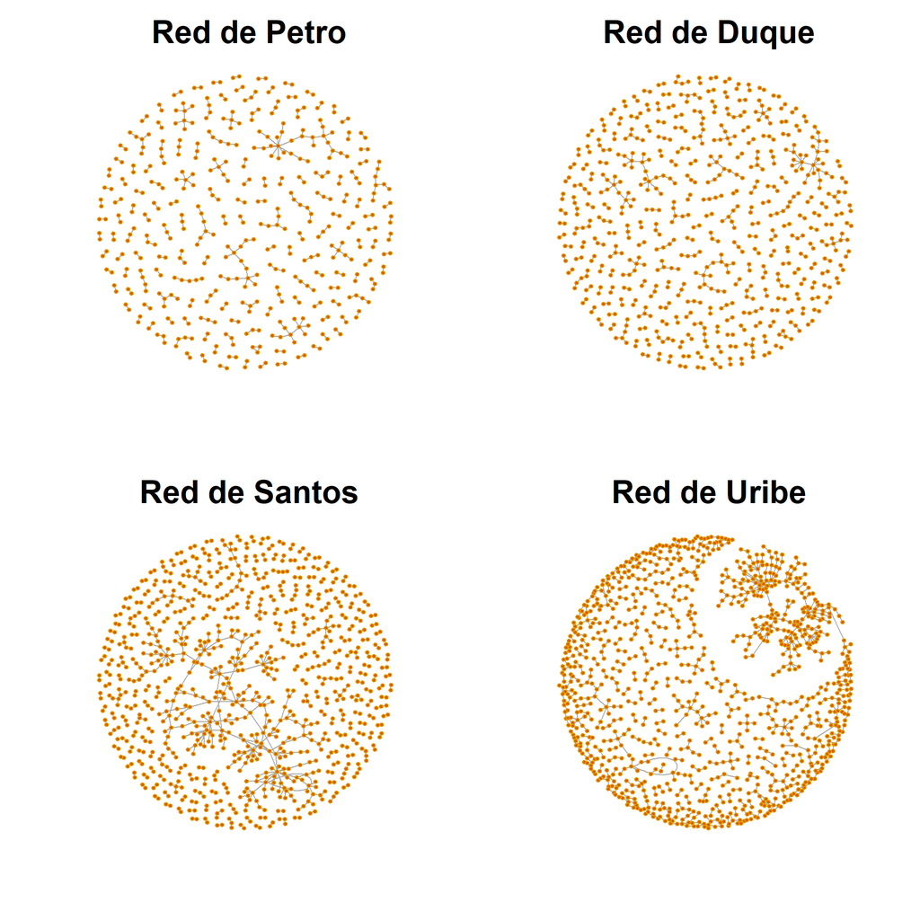

```r
##### definir una red a partir de la frecuencia (weight) de los bigramas
library(igraph)
g_petro <- text_petro_bi_counts %>%
  filter(weight > 0) %>%
  graph_from_data_frame(directed = FALSE)
g_duque <- text_duque_bi_counts %>%
  filter(weight > 0) %>%
  graph_from_data_frame(directed = FALSE)
g_santos <- text_santos_bi_counts %>%
  filter(weight > 0) %>%
  graph_from_data_frame(directed = FALSE)
g_uribe <- text_uribe_bi_counts %>%
  filter(weight > 0) %>%
  graph_from_data_frame(directed = FALSE)
# viz
par(mfrow=c(2,2), cex.main=2.5)
set.seed(176)
plot(g_petro, layout = layout_with_fr, vertex.color = 6, vertex.frame.color = 1, vertex.size = 3, vertex.label = NA, main = " Red de Petro")

plot(g_duque, layout = layout_with_fr, vertex.color = 6, vertex.frame.color = 1, vertex.size = 3, vertex.label = NA, main = " Red de Duque")

plot(g_santos, layout = layout_with_fr, vertex.color = 6, vertex.frame.color = 1, vertex.size = 3, vertex.label = NA, main = " Red de Santos")

plot(g_uribe, layout = layout_with_kk, vertex.color = 6, vertex.frame.color = 1, vertex.size = 3, vertex.label = NA, main = " Red de Uribe")
```

En el siguiente gráfico se muestran las componentes conexas más grandes en cada red, pero las etiquetas se omiten en las figuras de las estructuras de estas componentes para las redes de Santos y de Uribe par auna mejor visuliazación. Además, el tamaño de los nodos es proporcional a la fuerza de los mismos.

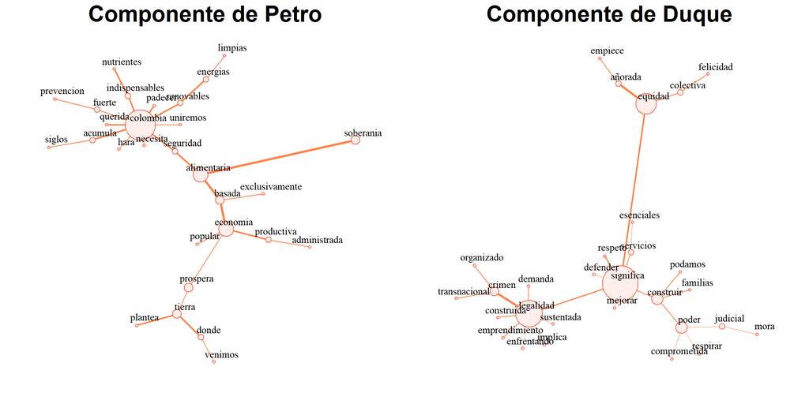

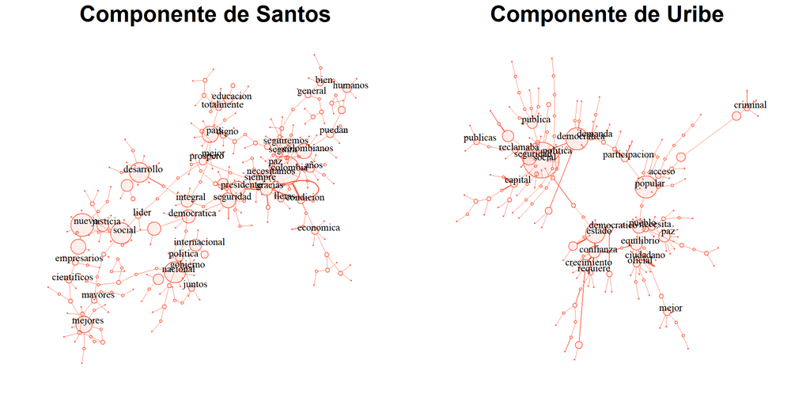

Para una mejor interpretación, se crean nuevamente dos redes para los bigramas de los discursos de Santos y Uribe pero filtrando por los que tengan una frecuencia mayor o igual que 2.

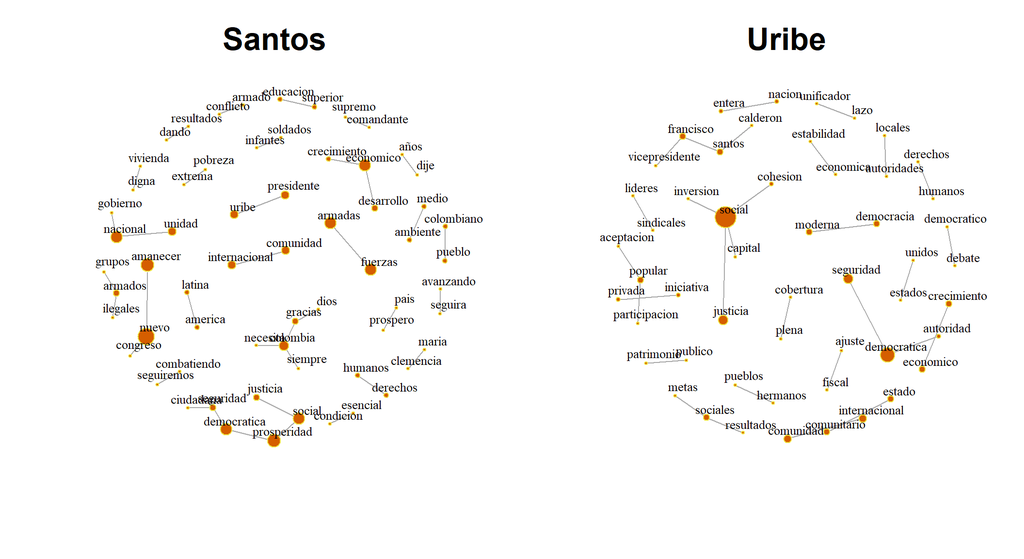

A partir de la componente gigante para cada funcionario se calculan las principales estadísticas descriptivas para cada red, las cuales nos permitirán observar de una mejor manera la cohesión en los discursos.

|  | Petro | Duque | Santos | Uribe |
| --- | --- | --- | --- | --- |
| Dist. media | 4.96 | 5.16 | 12.30 | 9.89 |
| Grado media | 1.93 | 1.93 | 2.08 | 2.04 |
| Grado desviación | 1.75 | 1.79 | 1.87 | 1.92 |
| Número clan | 2.00 | 2.00 | 3.00 | 3.00 |
| Densidad | 0.07 | 0.07 | 0.01 | 0.01 |
| Transitividad | 0.00 | 0.00 | 0.01 | 0.00 |
| Asortatividad | -0.36 | -0.37 | -0.23 | -0.23 |

# 11 Conclusiones de los bigramas.

A partir de la revisión de los bigramas más frecuentes en cada discurso, es posible apreciar las diferentes temáticas abarcadas en cada uno. El discurso de Petro muestra un carácter ambiental y económico al destacar expresiones como “selva amazónica”, “cambio climático”, “soberanía alimentaria”, “caminos comunes” y “comercio internacional”, mientras que le de Duque muestra una temática administrativa, donde se mencionan “sectores productivos”, “bienes públicos” y “administración pública”. Por su parte, los discursos de Santos tratan objetivos de su gobierno, tales como “unidad nacional”, “desarrollo económico” y “prosperidad democrática”, al igual que los de Uribe muestran fatores característicos de sus mandatos, como lo son “seguridad democrática”, “Estado comunitario” e “iniciativa privada”. Las expresiones “comunidad internacional” y “crecimiento económico” solo están en el top 10 de Uribe y de Santos.

# 12 Skip-grams

Otra forma de realizar el análisis de los bigramas es por medio de los skip-gramas. Método en el cual se crean parejas de palabras omitiendo una palabra de por medio.

```r
#tokenizar en skip-gram

text_petro %>%
  unnest_tokens(tbl = ., input = text, output = skipgram, token = "skip_ngrams", n = 2) %>%
  filter(!is.na(skipgram)) -> text_petro_skip
dim(text_petro_skip)
```

```
## [1] 10790     2
```

```r
text_duque %>%
  unnest_tokens(tbl = ., input = text, output = skipgram, token = "skip_ngrams", n = 2) %>%
  filter(!is.na(skipgram)) -> text_duque_skip
dim(text_duque_skip)
```

```
## [1] 14878     2
```

```r
text_santos %>%
  unnest_tokens(tbl = ., input = text, output = skipgram, token = "skip_ngrams", n = 2) %>%
  filter(!is.na(skipgram)) -> text_santos_skip
dim(text_santos_skip)
```

```
## [1] 23785     2
```

```r
text_uribe %>%
  unnest_tokens(tbl = ., input = text, output = skipgram, token = "skip_ngrams", n = 2) %>%
  filter(!is.na(skipgram)) -> text_uribe_skip
dim(text_uribe_skip)
```

```
## [1] 17948     2
```

Lo anterior almacena primero cada palabra, luego los bigramas usuales y por último el bigrama obtenido de eliminar la palabra de por medio. De este modo, se hace el conteo de palabras en cada fila, para eliminar los unigramas que ya fueron analizados anteriormente.

```r
library(ngram)
# contar palabras en cada skip-gram
text_petro_skip$num_words <- text_petro_skip$skipgram %>%
  map_int(.f = ~ wordcount(.x))
text_duque_skip$num_words <- text_duque_skip$skipgram %>%
  map_int(.f = ~ wordcount(.x))
text_santos_skip$num_words <- text_santos_skip$skipgram %>%
  map_int(.f = ~ wordcount(.x))
text_uribe_skip$num_words <- text_uribe_skip$skipgram %>%
  map_int(.f = ~ wordcount(.x))

# remover unigramas
text_petro_skip %<>%
  filter(num_words == 2) %>%
  select(-num_words)
dim(text_petro_skip)
```

```
## [1] 6950    2
```

```r
text_duque_skip %<>%
  filter(num_words == 2) %>%
  select(-num_words)
dim(text_duque_skip)
```

```
## [1] 9724    2
```

```r
text_santos_skip %<>%
  filter(num_words == 2) %>%
  select(-num_words)
dim(text_santos_skip)
```

```
## [1] 15464     2
```

```r
text_uribe_skip %<>%
  filter(num_words == 2) %>%
  select(-num_words)
dim(text_uribe_skip)
```

```
## [1] 11664     2
```

Una vez más, se decartan todos los registros que contengan alguna stop word, y simultánemente se eliminan los registros que contenían algún número.

```r
##### omitir stop words
text_petro_skip %>%
  separate(skipgram, c("word1", "word2"), sep = " ") %>%
  filter(!grepl(pattern = '[0-9]', x = word1)) %>%
  filter(!grepl(pattern = '[0-9]', x = word2)) %>%
  filter(!word1 %in% stop_words_es$word) %>%
  filter(!word2 %in% stop_words_es$word) %>%
  mutate(word1 = chartr(old = names(replacement_list) %>% str_c(collapse = ''),
                       new = replacement_list %>% str_c(collapse = ''),
                       x = word1)) %>%
  mutate(word2 = chartr(old = names(replacement_list) %>% str_c(collapse = ''),
                       new = replacement_list %>% str_c(collapse = ''),
                       x = word2)) %>%
  filter(!is.na(word1)) %>%
  filter(!is.na(word2)) %>%
  count(word1, word2, sort = TRUE) %>%
  rename(weight = n) -> text_petro_skip_counts
dim(text_petro_skip_counts)
```

```
## [1] 871   3
```

```r
text_duque_skip %>%
  separate(skipgram, c("word1", "word2"), sep = " ") %>%
  filter(!grepl(pattern = '[0-9]', x = word1)) %>%
  filter(!grepl(pattern = '[0-9]', x = word2)) %>%
  filter(!word1 %in% stop_words_es$word) %>%
  filter(!word2 %in% stop_words_es$word) %>%
  mutate(word1 = chartr(old = names(replacement_list) %>% str_c(collapse = ''),
                       new = replacement_list %>% str_c(collapse = ''),
                       x = word1)) %>%
  mutate(word2 = chartr(old = names(replacement_list) %>% str_c(collapse = ''),
                       new = replacement_list %>% str_c(collapse = ''),
                       x = word2)) %>%
  filter(!is.na(word1)) %>%
  filter(!is.na(word2)) %>%
  count(word1, word2, sort = TRUE) %>%
  rename(weight = n) -> text_duque_skip_counts
dim(text_duque_skip_counts)
```

```
## [1] 1194    3
```

```r
text_santos_skip %>%
  separate(skipgram, c("word1", "word2"), sep = " ") %>%
  filter(!grepl(pattern = '[0-9]', x = word1)) %>%
  filter(!grepl(pattern = '[0-9]', x = word2)) %>%
  filter(!word1 %in% stop_words_es$word) %>%
  filter(!word2 %in% stop_words_es$word) %>%
  mutate(word1 = chartr(old = names(replacement_list) %>% str_c(collapse = ''),
                       new = replacement_list %>% str_c(collapse = ''),
                       x = word1)) %>%
  mutate(word2 = chartr(old = names(replacement_list) %>% str_c(collapse = ''),
                       new = replacement_list %>% str_c(collapse = ''),
                       x = word2)) %>%
  filter(!is.na(word1)) %>%
  filter(!is.na(word2)) %>%
  count(word1, word2, sort = TRUE) %>%
  rename(weight = n) -> text_santos_skip_counts
dim(text_santos_skip_counts)
```

```
## [1] 1954    3
```

```r
text_uribe_skip %>%
  separate(skipgram, c("word1", "word2"), sep = " ") %>%
  filter(!grepl(pattern = '[0-9]', x = word1)) %>%
  filter(!grepl(pattern = '[0-9]', x = word2)) %>%
  filter(!word1 %in% stop_words_es$word) %>%
  filter(!word2 %in% stop_words_es$word) %>%
  mutate(word1 = chartr(old = names(replacement_list) %>% str_c(collapse = ''),
                       new = replacement_list %>% str_c(collapse = ''),
                       x = word1)) %>%
  mutate(word2 = chartr(old = names(replacement_list) %>% str_c(collapse = ''),
                       new = replacement_list %>% str_c(collapse = ''),
                       x = word2)) %>%
  filter(!is.na(word1)) %>%
  filter(!is.na(word2)) %>%
  count(word1, word2, sort = TRUE) %>%
  rename(weight = n) -> text_uribe_skip_counts
dim(text_uribe_skip_counts)
```

```
## [1] 2071    3
```

Ahora, se crean los grafos de los discursos con base en los skipgramas. A continuación se grafica la componente conexa más grande en cada discurso.

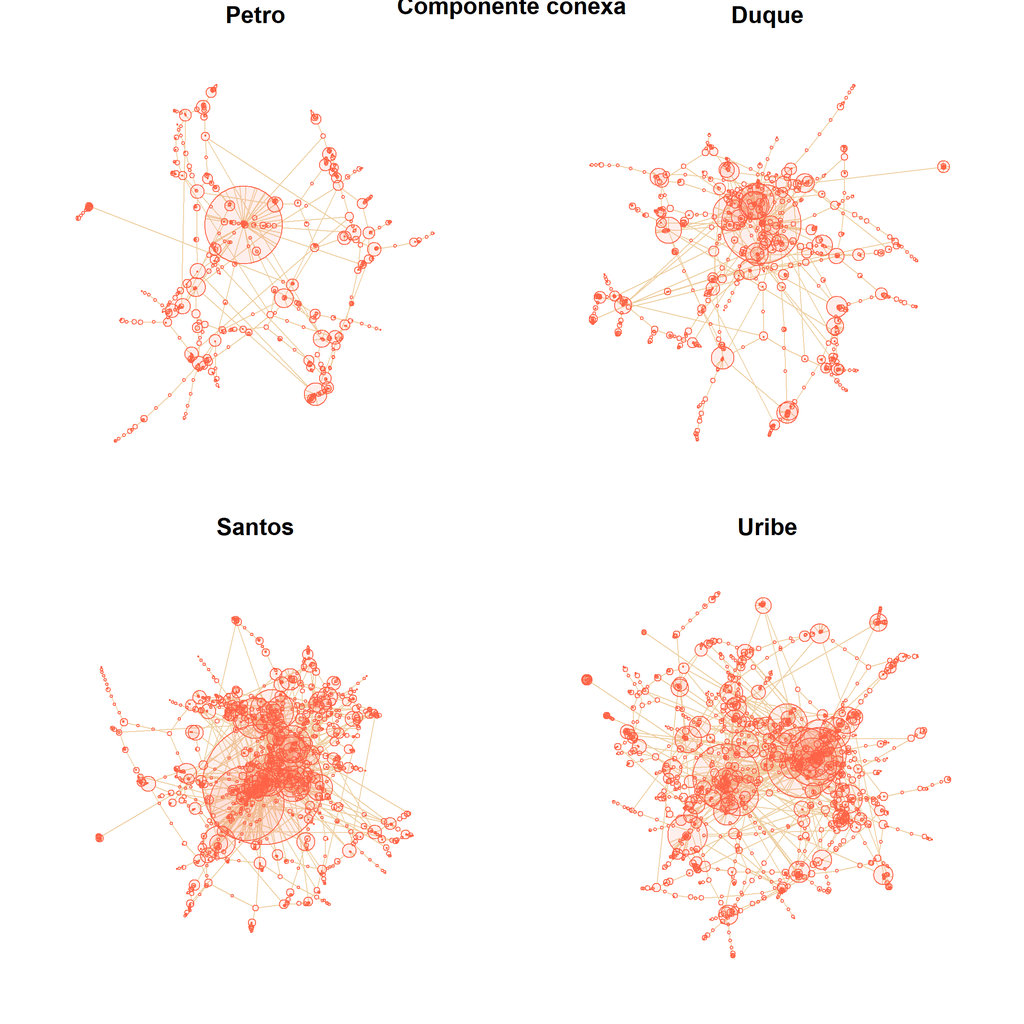

```r
### petro #########################
g2_petro <- text_petro_skip_counts %>%
  filter(weight > 0) %>%
  graph_from_data_frame(directed = FALSE)
g2_petro <- igraph::simplify(g2_petro)
V(g2_petro)$cluster <- clusters(graph = g2_petro)$membership
gcc2_petro <- induced_subgraph(graph = g2_petro, vids = which(V(g2_petro)$cluster == which.max(clusters(graph = g2_petro)$csize)))

### duque #########################
g2_duque <- text_duque_skip_counts %>%
  filter(weight > 0) %>%
  graph_from_data_frame(directed = FALSE)
g2_duque <- igraph::simplify(g2_duque)
V(g2_duque)$cluster <- clusters(graph = g2_duque)$membership
gcc2_duque <- induced_subgraph(graph = g2_duque, vids = which(V(g2_duque)$cluster == which.max(clusters(graph = g2_duque)$csize)))

### santos #########################
g2_santos <- text_santos_skip_counts %>%
  filter(weight > 0) %>%
  graph_from_data_frame(directed = FALSE)
g2_santos <- igraph::simplify(g2_santos)
V(g2_santos)$cluster <- clusters(graph = g2_santos)$membership
gcc2_santos <- induced_subgraph(graph = g2_santos, vids = which(V(g2_santos)$cluster == which.max(clusters(graph = g2_santos)$csize)))

### uribe #########################
g2_uribe <- text_uribe_skip_counts %>%
  filter(weight > 0) %>%
  graph_from_data_frame(directed = FALSE)
g2_uribe <- igraph::simplify(g2_uribe)
V(g2_uribe)$cluster <- clusters(graph = g2_uribe)$membership
gcc2_uribe <- induced_subgraph(graph = g2_uribe, vids = which(V(g2_uribe)$cluster == which.max(clusters(graph = g2_uribe)$csize)))
```

Nuevamente se calculan las principales estadísticas descriptivas para estas nuevas redes, con el mismo propósito interpretativo.

|  | Petro | Duque | Santos | Uribe |
| --- | --- | --- | --- | --- |
| Dist. media | 8.61 | 5.16 | 7.13 | 9.89 |
| Grado media | 2.31 | 2.38 | 2.72 | 2.60 |
| Grado desviación | 2.25 | 2.17 | 3.13 | 2.48 |
| Número clan | 3.00 | 3.00 | 4.00 | 3.00 |
| Densidad | 0.00 | 0.00 | 0.00 | 0.00 |
| Transitividad | 0.06 | 0.06 | 0.06 | 0.08 |
| Asortatividad | -0.08 | -0.04 | -0.05 | 0.01 |

## 12.1 Palabras más importantes

Una ventaja de realizar el análisis de redes con los bigramas y skipgramas, es que podemos hacer una clasificación del top 10 de las palabras más importantes en cada alocución, por medio de medidas como la centralidad propia de los vértices. Cabe aclarar que este tipo de centralidad nos mostrará las palabras de mayor importancia de acuerdo a la importancia de las demás palabras con las que se relacionan.

### Petro: Top 10

```
## # A tibble: 10 × 2
##    word          eigen
##    <chr>         <dbl>
##  1 colombia      1
##  2 mujeres       0.278
##  3 empieza       0.274
##  4 rincon        0.268
##  5 soñamos       0.268
##  6 latinoamerica 0.194
##  7 seguridad     0.185
##  8 acumula       0.179
##  9 padecer       0.179
## 10 corazon       0.173
```

### Duque: Top 10

```
## # A tibble: 10 × 2
##    word      eigen
##    <chr>     <dbl>
##  1 colombia  1
##  2 significa 0.910
##  3 equidad   0.892
##  4 legalidad 0.617
##  5 construir 0.349
##  6 gobernar  0.348
##  7 necesita  0.314
##  8 futuro    0.243
##  9 pacto     0.212
## 10 jovenes   0.209
```

### Santos: Top 10

```
## # A tibble: 10 × 2
##    word     eigen
##    <chr>    <dbl>
##  1 colombia 1
##  2 paz      0.668
##  3 pais     0.298
##  4 hora     0.287
##  5 gracias  0.276
##  6 dios     0.254
##  7 equidad  0.232
##  8 necesita 0.207
##  9 siempre  0.203
## 10 vision   0.185
```

### Uribe: Top 10

```
## # A tibble: 10 × 2
##    word        eigen
##    <chr>       <dbl>
##  1 seguridad   1
##  2 social      0.940
##  3 democratica 0.801
##  4 justicia    0.648
##  5 estado      0.484
##  6 paz         0.439
##  7 cohesion    0.284
##  8 autoridad   0.270
##  9 reclamaba   0.268
## 10 demanda     0.268
```

## 12.2 Agrupamiento

Finalmente, para concluir el análisis a los discursos se realiza un agrupamiento en cada una de las componentes gigantes de estos últimos grafos creados a partir de los skip-gramas. Los grupos resultantes son útiles para identificar los distintos tipos de temáticas dentro de los discursos. Adicionalmente, se observa el top 5 de palabras más importantes, de acuerdo a la centralidad propia, dentro del grupo con mayor cantidad de vértices en cada agrupamiento.

|  | Petro | Duque | Santos | Uribe |
| --- | --- | --- | --- | --- |
| Tamaño partición | 25 | 29 | 34 | 38 |
| Tamaño grupo menor | 10 | 5 | 4 | 5 |
| Tamaño grupo mayor | 44 | 69 | 147 | 99 |

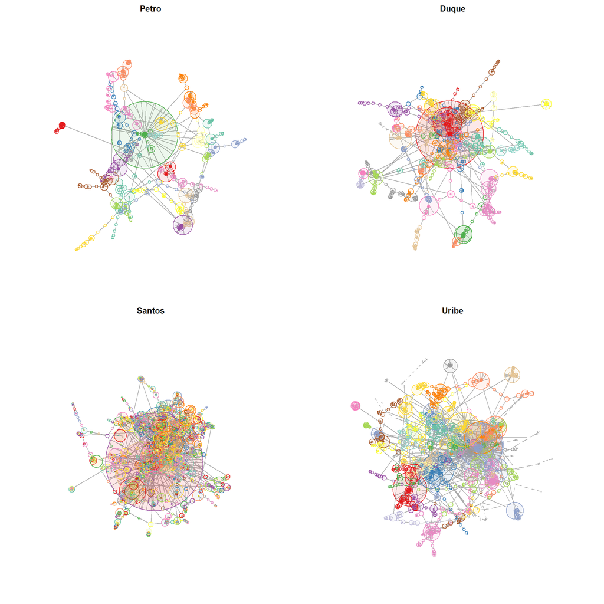

### Petro: Top 5 grupo mayor

```
## # A tibble: 5 × 3
##   word     cluster eigen
##   <chr>      <dbl> <dbl>
## 1 colombia       3 1
## 2 mujeres        3 0.278
## 3 empieza        3 0.274
## 4 rincon         3 0.268
## 5 soñamos        3 0.268
```

### Duque: Top 5 grupo mayor

```
## # A tibble: 5 × 3
##   word      cluster eigen
##   <chr>       <dbl> <dbl>
## 1 colombia        1 1
## 2 significa       1 0.910
## 3 equidad         1 0.892
## 4 legalidad       1 0.617
## 5 gobernar        1 0.348
```

### Santos: Top 5 grupo mayor

```
## # A tibble: 5 × 3
##   word        cluster  eigen
##   <chr>         <dbl>  <dbl>
## 1 justicia          5 0.141
## 2 economico         5 0.128
## 3 social            5 0.126
## 4 familias          5 0.0803
## 5 prosperidad       5 0.0697
```

### Uribe: Top 5 grupo mayor

```
## # A tibble: 5 × 3
##   word        cluster eigen
##   <chr>         <dbl> <dbl>
## 1 seguridad        12 1
## 2 democratica      12 0.801
## 3 paz              12 0.439
## 4 autoridad        12 0.270
## 5 demanda          12 0.268
```

# 13 Conclusiones Skip-gramas

Al añadir a las unidades de análisis todos los skip-gramas, se incrementa claramente el tamaño de la componente conexa en cada discurso. Comparando las estadísticas descriptivas contra las obtenidas en las componentes gigantes de únicamente los bigramas, en general, aumenta el promedio y la desviación del grado, al igual que el número clan y, considerablemente, la transitividad, lo cual es acorde al aumento de las relaciones generadas por los skipgramas. Sin embargo, la densidad disminuye y la asortatividad con respecto al grado es más cercana a cero, cosa que puede ser un indicador de que, aunque hayan frases compuestas de las mismas palabras con mucha frecuencia a lo largo del discurso, estas son utilizadas para hablar sobre distintos temas particulares, al relacionarse de igual manera con otras palabras que no son muy frecuentes, marcando un patrón de cohesión y coherencia en las alocuciones.

Por otro lado, al hacer la revisión de las palabras más importantes, se muestran diferencias más evidentes entre los discursos. Se observa un panorama más sentimentalista en el texto de Petro al usar palabras como “soñamos”, “corazon” y “padecer”; la aparición de la palabra “mujeres” como la segunda más importante confirma la diferencia en cuanto a inclusión mencionada anteriormente. Para Duque nuevamente se evidencian actitudes emprendedoras denotadas en palabras como “construir”, “gobernar” y “futuro”; además, resalta por mencionar a los jóvenes. Para Santos no se distingue un tema especial, más allá de que se diferencia por intensificar el uso de la palabra “gracias” y “Dios”. Finalmente, Uribe muestra palabras más singulares y de carácter fuerte como “seguridad”, “Autoridad”, “democratica” y “estado”.

Por último, los resultados del agrupamiento en las componentes gigantes señalan que son muchos los temas tratados en todas las alocuciones y que, naturalmente, es mayor la cantidad de particiones para Santos y Uribe que para Petro y Duque, puesto que, en dos discursos unificados, el posible número de temas a tratar es mayor, aunque el tamaño de la mayor partición en cada texto varía considerablemente.

Además, al hacer una primera revisión a la lista de palabras más importantes dentro de la partición más grande en cada texto, se aprecia la misma tendencia de temáticas e intensión que se ha interpretado en los procedimientos anteriores.

Para finalizar y reuniendo todos lo resultados e interpretaciones obtenidas con el análisis, se hallaron varias similitudes en lo que respecta a la estructura de estos. Sin embargo, son claros los contrates en cuanto a las temáticas en las que se hace énfasis y en ciertas expresiones que marcan la intensión de cada discurso, evidenciando que las diferencias en entre las visiones y prioridades de cada mandatario, las cuales pueden dar sentido a sus acciones durante su respectivo gobierno.